# INE–IGM Spatial Inspection: Multi-Code Points

Manual review of IGM points claimed by multiple INE community codes via unique_via_spatial resolution

Published

April 28, 2026

```r
library(tidyverse)
library(sf)
library(ggplot2)

# Crosswalk (loads crosswalk_geo_ine)
source(here::here("ine_community_mapping.R"))

# Spatial helper functions (point_to_municipality, inspect_shared_point)
source(here::here("src", "point_municipality_lookup.R"))

# IGM geographic points
geo <- st_read(here::here("data", "geocode", "localizacion_poblaciones_2016.json"), quiet = TRUE)

# GADM municipality boundaries (with INE cod.mun, saved from ine_community_mapping.R)
mun_sf <- readRDS(here::here("data", "mun_sf.rds"))
```

```r
# Reproduce the same_mun_ids / cross_mun_ids vectors used in the main analysis
multi_code_id <- crosswalk_geo_ine |>
  filter(match_status == "unique_via_spatial") |>
  count(id_unico) |>
  filter(n > 1) |>
  pull(id_unico)

same_mun_ids <- crosswalk_geo_ine |>
  filter(match_status == "unique_via_spatial", id_unico %in% multi_code_id) |>
  group_by(id_unico) |>
  filter(n_distinct(municipality) == 1) |>
  pull(id_unico) |>
  unique()

cross_mun_ids <- crosswalk_geo_ine |>
  filter(match_status == "unique_via_spatial", id_unico %in% multi_code_id) |>
  group_by(id_unico) |>
  filter(n_distinct(municipality) > 1) |>
  pull(id_unico) |>
  unique()
```

## 1 Background

During crosswalk construction, `unique_via_spatial` codes were resolved by selecting the single IGM candidate whose GADM municipality polygon contained the INE code’s municipality. When multiple INE codes were resolved this way and all converged on the same IGM point, that point appears here.

There are two distinct patterns:

- **Same-municipality cases** (13 points): all converging codes are in the same INE municipality. Pattern is consistent with canton renumbering, analogous to `unique_via_name` duplicates.
- **Cross-municipality cases** (48 points): converging codes span *different* INE municipalities. A single IGM point serves as the resolved location for communities in multiple municipalities — whether due to a common place name or incomplete IGM coverage is unresolved.

**Important**: Bolivia expanded from roughly 100 to 340 municipalities between 1994 and 2010. The GADM boundaries represent the current (~340-municipality) structure; INE codes in this crosswalk may reflect earlier, broader municipal units. No single answer is assumed correct. Each map below shows:

- **Colored polygons**: all GADM municipality boundaries referenced by INE codes mapping to this point
- **Thick gray border**: the municipality currently containing the point (GADM)
- **Red dot**: the IGM point itself

## 2 Same-Municipality Cases (13 points)

All converging codes are within a single INE municipality. Likely canton renumbering — the same community appears under multiple codes as canton boundaries were redrawn over time.

```r
same_mun_results <- purrr::map(same_mun_ids, inspect_shared_point)

for (result in same_mun_results) {
  cat("\n\n###", result$heading, "\n\n")
  cat("**Current GADM municipality:**", result$current_mun_label, "\n\n")
  if (length(result$unmatched_muns) > 0) {
    cat(paste0(
      "**\u26a0 Municipality names not in current GADM (historical boundaries):** ",
      paste(result$unmatched_muns, collapse = ", "), "\n\n"
    ))
  }
  cat(knitr::kable(result$table, format = "pipe") |> paste(collapse = "\n"))
  cat("\n\n")
  print(result$map)
  cat("\n\n---\n\n")
}
```

### 2.1 MACHACAMARCA — 5772355832-D

**Current GADM municipality:** Colquencha (La Paz)

| INE Code | Name | INE Municipality | Department | Match Status | = Current GADM |
| --- | --- | --- | --- | --- | --- |
| 02130603002 | MACHACAMARCA | Colquencha | La Paz | unique_via_spatial | ✓ |
| 02130605001 | MACHACAMARCA | Colquencha | La Paz | unique_via_spatial | ✓ |
| 02120101801 | MACHACAMARCA | Pucarani | La Paz | ambiguous_dispersed |  |

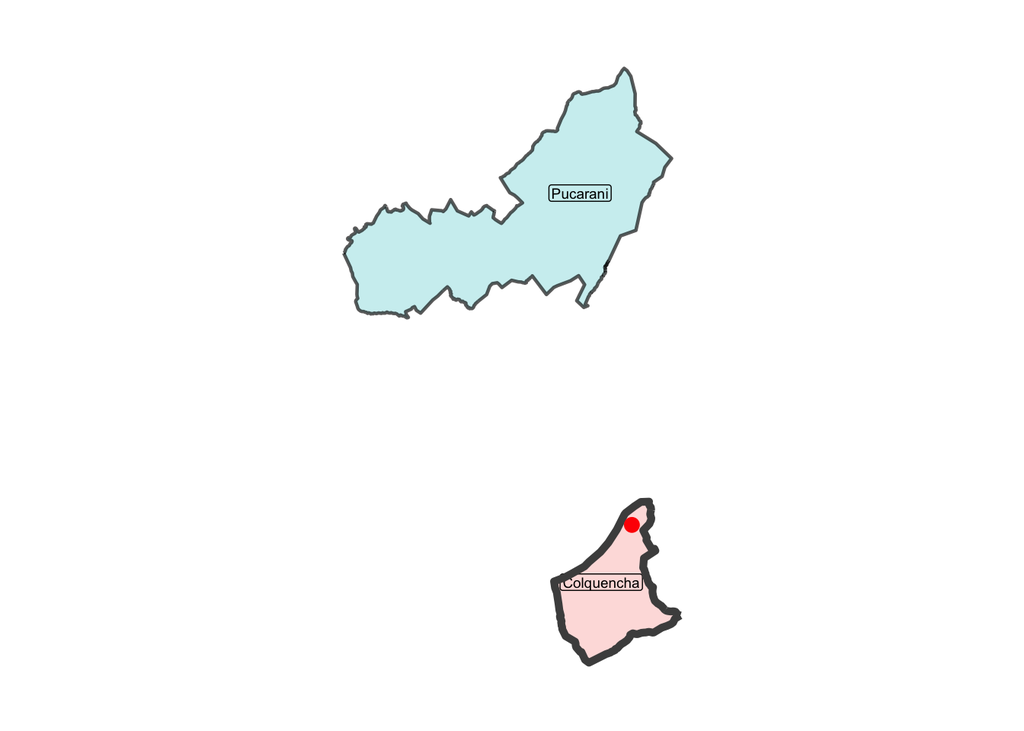

### 2.2 AGUAS VERDES — 6739541086-D

**Current GADM municipality:** Caranavi (La Paz)

| INE Code | Name | INE Municipality | Department | Match Status | = Current GADM |
| --- | --- | --- | --- | --- | --- |
| 02200115003 | AGUAS VERDES | Caranavi | La Paz | unique_via_spatial | ✓ |
| 02200116003 | AGUAS VERDES | Caranavi | La Paz | unique_via_spatial | ✓ |

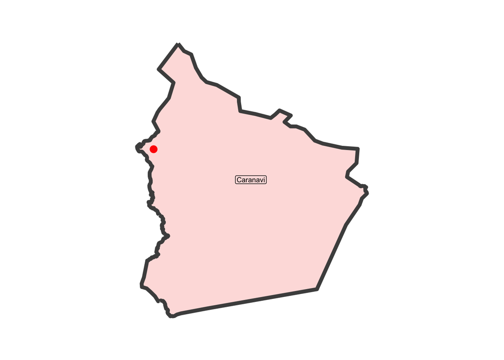

### 2.3 VILLA SAN JOSE — 6763530554-D

**Current GADM municipality:** Caranavi (La Paz)

| INE Code | Name | INE Municipality | Department | Match Status | = Current GADM |
| --- | --- | --- | --- | --- | --- |
| 02200116007 | VILLA SAN JOSE | Caranavi | La Paz | unique_via_spatial | ✓ |
| 02200122013 | VILLA SAN JOSE | Caranavi | La Paz | unique_via_spatial | ✓ |

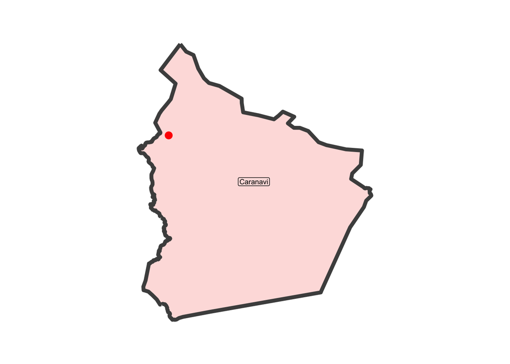

### 2.4 CHALLAQUE BAJO — 4931640176-D

**Current GADM municipality:** Sacabamba (Cochabamba)

| INE Code | Name | INE Municipality | Department | Match Status | = Current GADM |
| --- | --- | --- | --- | --- | --- |
| 03040402703 | CHALLAQUE BAJO | Sacabamba | Cochabamba | unique_via_spatial | ✓ |
| 03040403703 | CHALLAQUE BAJO | Sacabamba | Cochabamba | unique_via_spatial | ✓ |

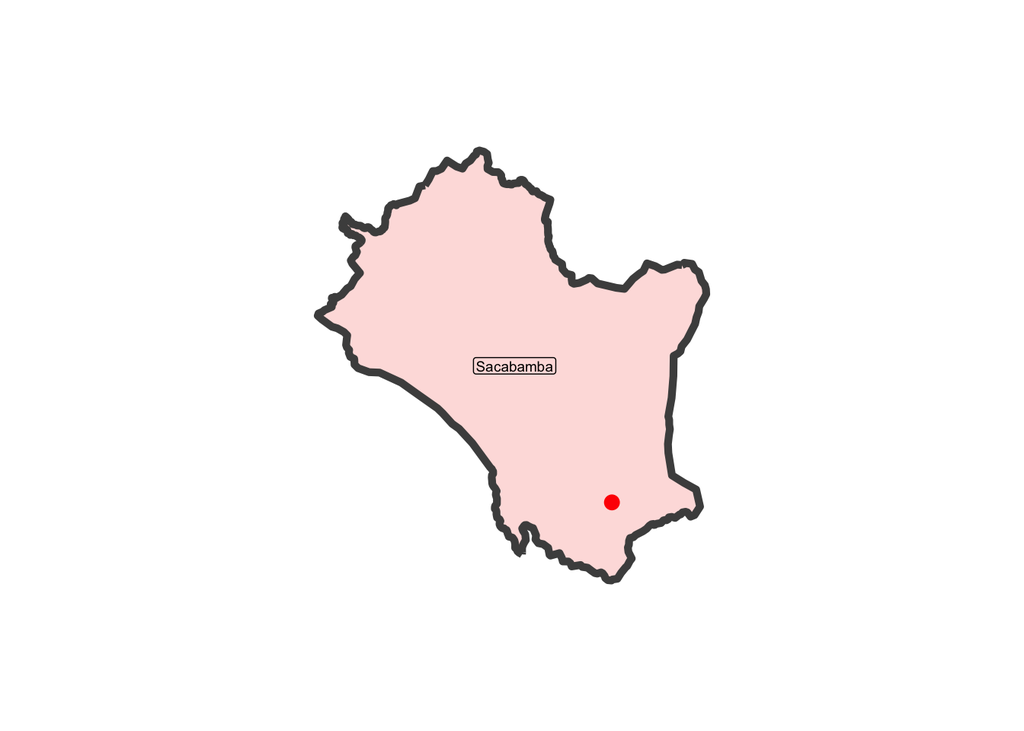

### 2.5 CALLAJ CHULLPA CHICO — 4870220031-D

**Current GADM municipality:** Arque (Cochabamba)

| INE Code | Name | INE Municipality | Department | Match Status | = Current GADM |
| --- | --- | --- | --- | --- | --- |
| 03060101860 | CALLAJ CHULLPA CHICO | Arque | Cochabamba | unique_via_spatial | ✓ |
| 03060102860 | CALLAJ CHULLPA CHICO | Arque | Cochabamba | unique_via_spatial | ✓ |

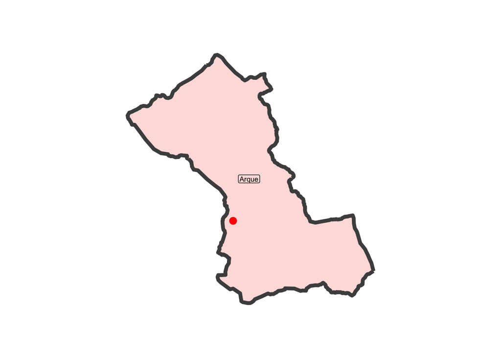

### 2.6 SANTA ISABEL — 5338356704-D

**Current GADM municipality:** Colomi (Cochabamba)

| INE Code | Name | INE Municipality | Department | Match Status | = Current GADM |
| --- | --- | --- | --- | --- | --- |
| 03100201190 | SANTA ISABEL | Colomi | Cochabamba | unique_via_spatial | ✓ |
| 03100203704 | SANTA ISABEL | Colomi | Cochabamba | unique_via_spatial | ✓ |

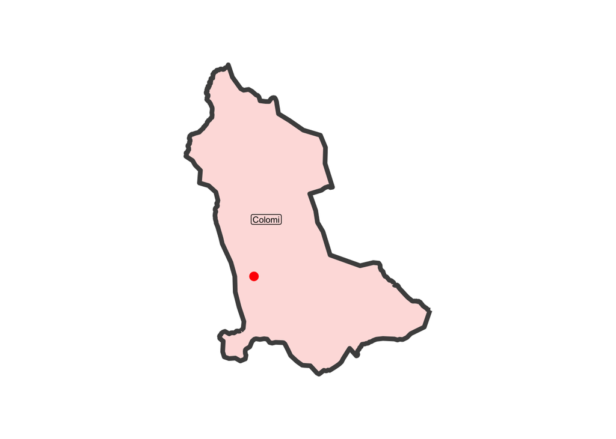

### 2.7 GUALBERTO VILLARROEL — 5465779448-D

**Current GADM municipality:** Puerto Villarroel (Cochabamba)

| INE Code | Name | INE Municipality | Department | Match Status | = Current GADM |
| --- | --- | --- | --- | --- | --- |
| 03120501745 | GUALBERTO VILLARROEL | Puerto Villarroel | Cochabamba | unique_via_spatial | ✓ |
| 03120504030 | GUALBERTO VILLARROEL | Puerto Villarroel | Cochabamba | unique_via_spatial | ✓ |

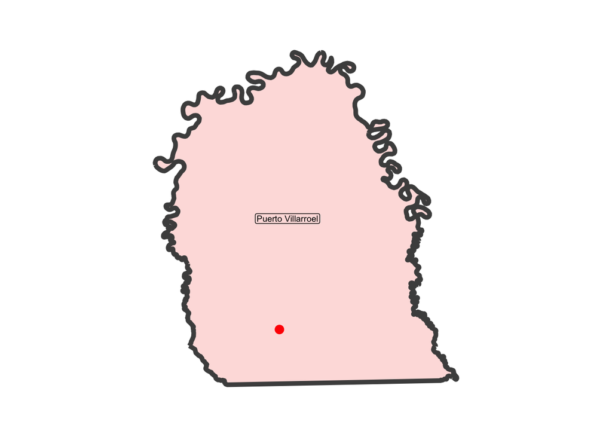

### 2.8 LAGUNILLAS — 5699063085-D

**Current GADM municipality:** Puerto Villarroel (Cochabamba)

| INE Code | Name | INE Municipality | Department | Match Status | = Current GADM |
| --- | --- | --- | --- | --- | --- |
| 03120501753 | LAGUNILLAS | Puerto Villarroel | Cochabamba | unique_via_spatial | ✓ |
| 03120503753 | LAGUNILLAS | Puerto Villarroel | Cochabamba | unique_via_spatial | ✓ |

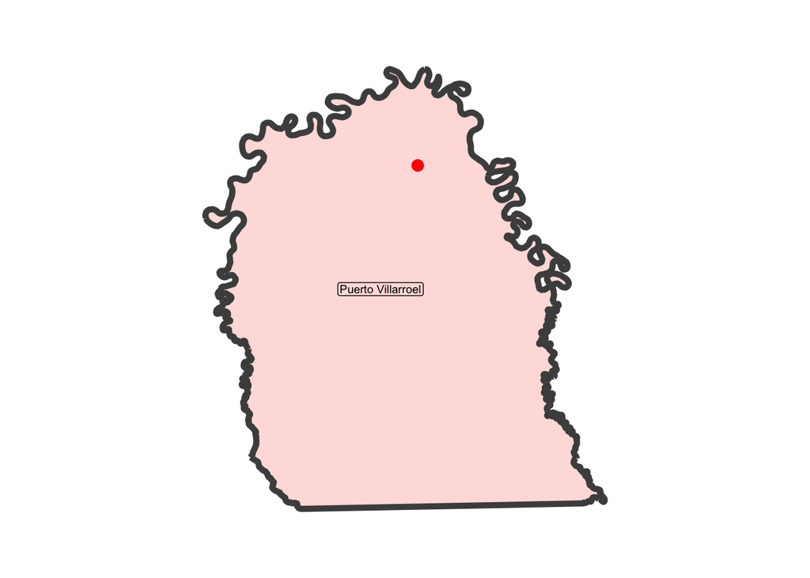

### 2.9 SAN ANTONIO — 5470411302-D

**Current GADM municipality:** Puerto Villarroel (Cochabamba)

| INE Code | Name | INE Municipality | Department | Match Status | = Current GADM |
| --- | --- | --- | --- | --- | --- |
| 03120502959 | SAN ANTONIO | Puerto Villarroel | Cochabamba | unique_via_spatial | ✓ |
| 03120504059 | SAN ANTONIO | Puerto Villarroel | Cochabamba | unique_via_spatial | ✓ |

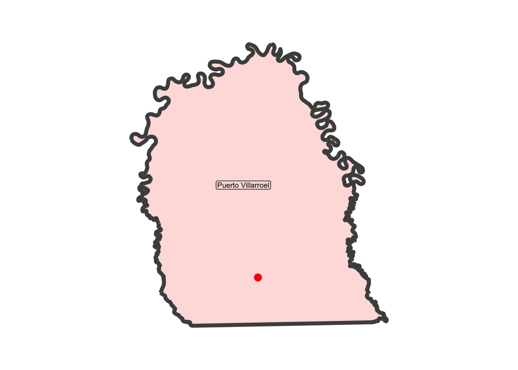

### 2.10 PALCA — 5244186557-D

**Current GADM municipality:** Tiraque (Cochabamba)

**⚠ Municipality names not in current GADM (historical boundaries):** Bolívar

| INE Code | Name | INE Municipality | Department | Match Status | = Current GADM |
| --- | --- | --- | --- | --- | --- |
| 03150101720 | PALCA | Bolívar | Cochabamba | ambiguous_dispersed |  |
| 03100101777 | PALCA | Sacaba | Cochabamba | ambiguous_dispersed |  |
| 03160101812 | PALCA | Tiraque | Cochabamba | unique_via_spatial | ✓ |
| 03160103025 | PALCA | Tiraque | Cochabamba | unique_via_spatial | ✓ |

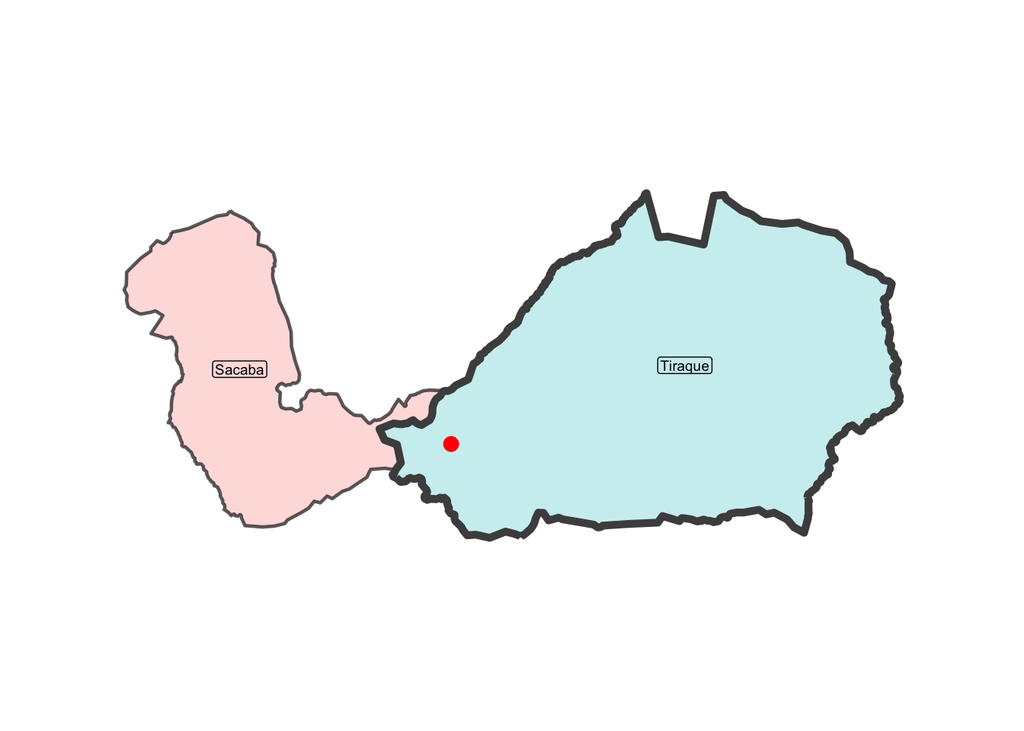

### 2.11 NUEVO ISRAEL — 7409118047-D

**Current GADM municipality:** San Javier (Beni)

| INE Code | Name | INE Municipality | Department | Match Status | = Current GADM |
| --- | --- | --- | --- | --- | --- |
| 08010201015 | NUEVO ISRAEL | San Javier | Beni | unique_via_spatial | ✓ |
| 08010202009 | NUEVO ISRAEL | San Javier | Beni | unique_via_spatial | ✓ |

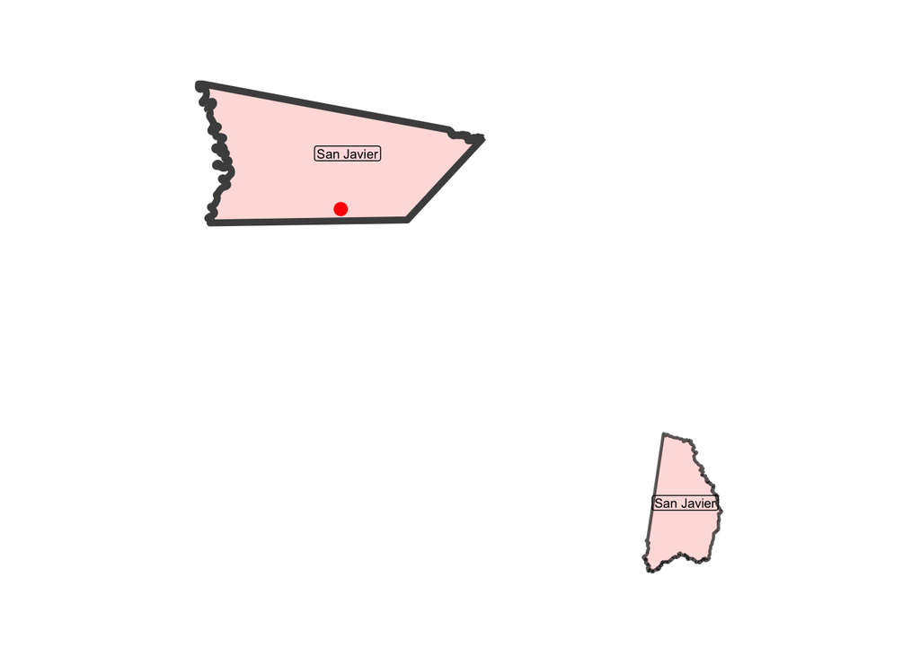

### 2.12 ROSARIO DEL YATA — 10945151949-D

**Current GADM municipality:** Guayaramerín (Beni)

| INE Code | Name | INE Municipality | Department | Match Status | = Current GADM |
| --- | --- | --- | --- | --- | --- |
| 08020201702 | ROSARIO DEL YATA | Guayaramerín | Beni | unique_via_spatial | ✓ |
| 08020204737 | ROSARIO DEL YATA | Guayaramerín | Beni | unique_via_spatial | ✓ |

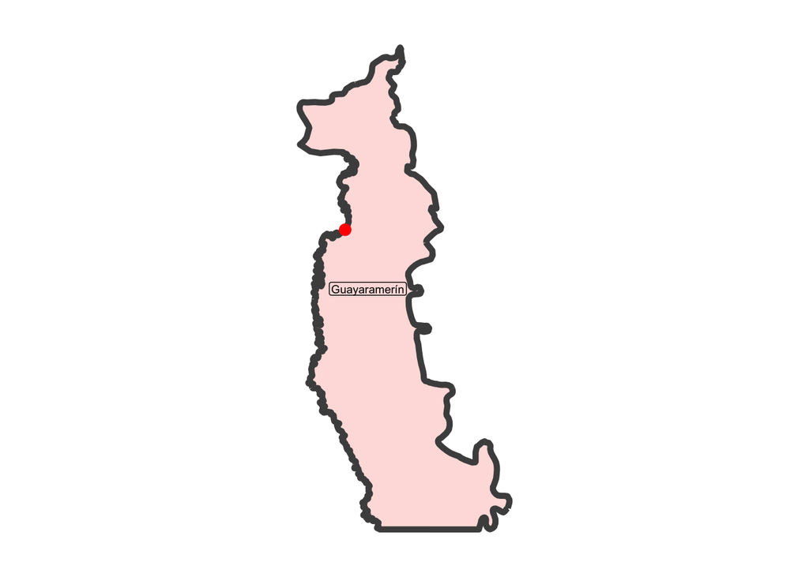

### 2.13 SACHOJERE — 7059818379-D

**Current GADM municipality:** Loreto (Beni)

| INE Code | Name | INE Municipality | Department | Match Status | = Current GADM |
| --- | --- | --- | --- | --- | --- |
| 08060101020 | SACHOJERE | Loreto | Beni | unique_via_spatial | ✓ |
| 08060103702 | SACHOJERE | Loreto | Beni | unique_via_spatial | ✓ |
| 08060104702 | SACHOJERE | Loreto | Beni | unique_via_spatial | ✓ |

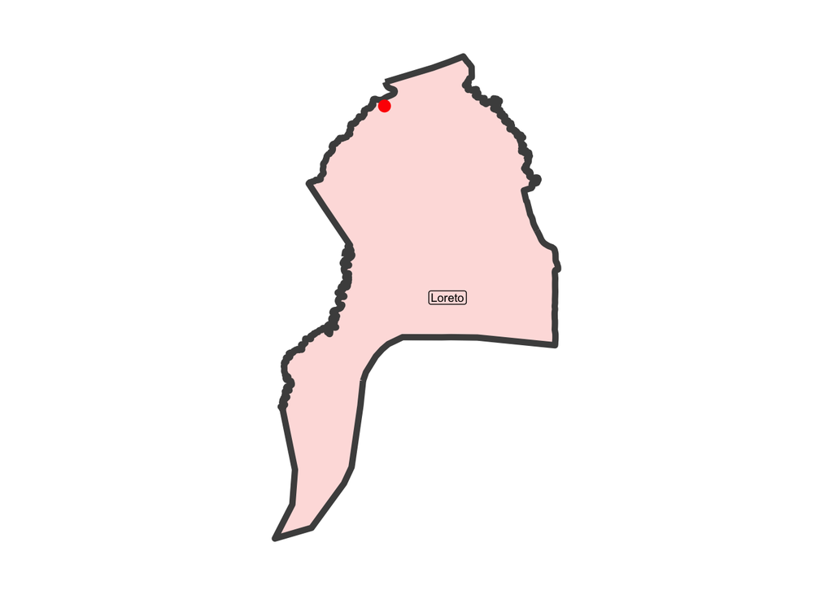

## 3 Cross-Municipality Cases (48 points)

Converging codes span *different* INE municipalities. Each map shows how far apart the referenced municipalities are, which helps assess whether convergence is plausible (nearby municipalities, shifted boundaries) or suspicious (distant municipalities, probably a common generic name with incomplete IGM coverage).

```r
# Sort by descending number of municipalities to show most complex cases first
cross_mun_order <- crosswalk_geo_ine |>
  filter(match_status == "unique_via_spatial", id_unico %in% cross_mun_ids) |>
  group_by(id_unico) |>
  summarise(n_mun = n_distinct(municipality), .groups = "drop") |>
  arrange(desc(n_mun)) |>
  pull(id_unico)

cross_mun_results <- purrr::map(cross_mun_order, inspect_shared_point)

for (result in cross_mun_results) {
  cat("\n\n###", result$heading, "\n\n")
  cat("**Current GADM municipality:**", result$current_mun_label, "\n\n")
  if (length(result$unmatched_muns) > 0) {
    cat(paste0(
      "**\u26a0 Municipality names not in current GADM (historical boundaries):** ",
      paste(result$unmatched_muns, collapse = ", "), "\n\n"
    ))
  }
  cat(knitr::kable(result$table, format = "pipe") |> paste(collapse = "\n"))
  cat("\n\n")
  print(result$map)
  cat("\n\n---\n\n")
}
```

### 3.1 VILUYO — 3548609828-D

**Current GADM municipality:** Outside GADM boundaries

**⚠ Municipality names not in current GADM (historical boundaries):** Caripuyo, Colcha “K”, Colquechaca, Llallagua, Ocurí, S.P. De Buena Vista, Tomave, Toro Toro, Uncía

| INE Code | Name | INE Municipality | Department | Match Status | = Current GADM |
| --- | --- | --- | --- | --- | --- |
| 05070204005 | VILUYO | Caripuyo | Potosi | unique_via_spatial | NA |
| 05090108017 | VILUYO | Colcha “K” | Potosi | unique_via_spatial | NA |
| 05040105040 | VILUYO | Colquechaca | Potosi | unique_via_spatial | NA |
| 05020301133 | VILUYO | Llallagua | Potosi | unique_via_spatial | NA |
| 05040402113 | VILUYO | Ocurí | Potosi | unique_via_spatial | NA |
| 05050103021 | VILUYO | S.P. De Buena Vista | Potosi | unique_via_spatial | NA |
| 05050106021 | VILUYO | S.P. De Buena Vista | Potosi | unique_via_spatial | NA |
| 05120201042 | VILUYO | Tomave | Potosi | unique_via_spatial | NA |
| 05050201076 | VILUYO | Toro Toro | Potosi | unique_via_spatial | NA |
| 05020101197 | VILUYO | Uncía | Potosi | unique_via_spatial | NA |

### 3.2 VILA VILA — 3976510393-D

**Current GADM municipality:** Outside GADM boundaries

**⚠ Municipality names not in current GADM (historical boundaries):** Betanzos, Chuquiuta, Colcha “K”, Pocoata, Tacobamba, Tomave, Villa de Sacaca

| INE Code | Name | INE Municipality | Department | Match Status | = Current GADM |
| --- | --- | --- | --- | --- | --- |
| 05030106046 | VILA VILA | Betanzos | Potosi | unique_via_spatial | NA |
| 05020402023 | VILA VILA | Chuquiuta | Potosi | unique_via_spatial | NA |
| 05090102003 | VILA VILA | Colcha “K” | Potosi | unique_via_spatial | NA |
| 05040302204 | VILA VILA | Pocoata | Potosi | unique_via_spatial | NA |
| 05030303003 | VILA VILA | Tacobamba | Potosi | unique_via_spatial | NA |
| 05120205033 | VILA VILA | Tomave | Potosi | unique_via_spatial | NA |
| 05070101274 | VILA VILA | Villa de Sacaca | Potosi | unique_via_spatial | NA |

### 3.3 AGUA DE CASTILLA — 3627785246-D

**Current GADM municipality:** Outside GADM boundaries

**⚠ Municipality names not in current GADM (historical boundaries):** Colcha “K”, Llallagua, Porco, Ravelo, San Agustín, Vitichi

| INE Code | Name | INE Municipality | Department | Match Status | = Current GADM |
| --- | --- | --- | --- | --- | --- |
| 05090108008 | AGUA DE CASTILLA | Colcha “K” | Potosi | unique_via_spatial | NA |
| 05020301083 | AGUA DE CASTILLA | Llallagua | Potosi | unique_via_spatial | NA |
| 05120301001 | AGUA DE CASTILLA | Porco | Potosi | unique_via_usca | NA |
| 05120304030 | AGUA DE CASTILLA | Porco | Potosi | unique_via_spatial | NA |
| 05040205029 | AGUA DE CASTILLA | Ravelo | Potosi | unique_via_spatial | NA |
| 05160103003 | AGUA DE CASTILLA | San Agustín | Potosi | unique_via_spatial | NA |
| 05060202001 | AGUA DE CASTILLA | Vitichi | Potosi | unique_via_spatial | NA |

### 3.4 UYUNI — 3092376739-D

**Current GADM municipality:** Outside GADM boundaries

**⚠ Municipality names not in current GADM (historical boundaries):** Chuquiuta, Ckochas, Llallagua, Tinguipaya, Uyuni

| INE Code | Name | INE Municipality | Department | Match Status | = Current GADM |
| --- | --- | --- | --- | --- | --- |
| 05020402062 | UYUNI | Chuquiuta | Potosi | unique_via_spatial | NA |
| 05110302028 | UYUNI | Ckochas | Potosi | unique_via_spatial | NA |
| 05020301036 | UYUNI | Llallagua | Potosi | unique_via_spatial | NA |
| 05010201702 | UYUNI | Tinguipaya | Potosi | unique_via_spatial | NA |
| 05120101002 | UYUNI | Uyuni | Potosi | unique_via_spatial | NA |

### 3.5 CALA CALA — 4386335572-D

**Current GADM municipality:** Outside GADM boundaries

**⚠ Municipality names not in current GADM (historical boundaries):** Chuquiuta, Potosí, Puna, Uncía, Uyuni

| INE Code | Name | INE Municipality | Department | Match Status | = Current GADM |
| --- | --- | --- | --- | --- | --- |
| 05020402033 | CALA CALA | Chuquiuta | Potosi | unique_via_spatial | NA |
| 05010104033 | CALA CALA | Potosí | Potosi | unique_via_spatial | NA |
| 05110101026 | CALA CALA | Puna | Potosi | unique_via_spatial | NA |
| 05110109026 | CALA CALA | Puna | Potosi | unique_via_spatial | NA |
| 05020101097 | CALA CALA | Uncía | Potosi | unique_via_spatial | NA |
| 05120103008 | CALA CALA | Uyuni | Potosi | unique_via_spatial | NA |

### 3.6 PEÑA BLANCA — 2666507222-D

**Current GADM municipality:** Outside GADM boundaries

**⚠ Municipality names not in current GADM (historical boundaries):** Colquechaca, Cotagaita, Llica, Tupiza

| INE Code | Name | INE Municipality | Department | Match Status | = Current GADM |
| --- | --- | --- | --- | --- | --- |
| 05040102203 | PEÑA BLANCA | Colquechaca | Potosi | unique_via_spatial | NA |
| 05060116101 | PEÑA BLANCA | Cotagaita | Potosi | unique_via_spatial | NA |
| 05140101031 | PEÑA BLANCA | Llica | Potosi | unique_via_spatial | NA |
| 05080101028 | PEÑA BLANCA | Tupiza | Potosi | unique_via_spatial | NA |

### 3.7 CHACOMA — 3383689624-D

**Current GADM municipality:** Outside GADM boundaries

**⚠ Municipality names not in current GADM (historical boundaries):** Llica, S.P. De Buena Vista, Tacobamba, Villa de Sacaca

| INE Code | Name | INE Municipality | Department | Match Status | = Current GADM |
| --- | --- | --- | --- | --- | --- |
| 05140104002 | CHACOMA | Llica | Potosi | unique_via_spatial | NA |
| 05050101038 | CHACOMA | S.P. De Buena Vista | Potosi | unique_via_spatial | NA |
| 05030304058 | CHACOMA | Tacobamba | Potosi | unique_via_spatial | NA |
| 05070101173 | CHACOMA | Villa de Sacaca | Potosi | unique_via_spatial | NA |

### 3.8 SAN ANTONIO — 3773882390-D

**Current GADM municipality:** Outside GADM boundaries

**⚠ Municipality names not in current GADM (historical boundaries):** Betanzos, Cotagaita, Vitichi, Yocalla

| INE Code | Name | INE Municipality | Department | Match Status | = Current GADM |
| --- | --- | --- | --- | --- | --- |
| 05030109029 | SAN ANTONIO | Betanzos | Potosi | unique_via_spatial | NA |
| 05060112002 | SAN ANTONIO | Cotagaita | Potosi | unique_via_spatial | NA |
| 05060201019 | SAN ANTONIO | Vitichi | Potosi | unique_via_spatial | NA |
| 05010303023 | SAN ANTONIO | Yocalla | Potosi | unique_via_spatial | NA |

### 3.9 JACHOJO — 4501911777-D

**Current GADM municipality:** Outside GADM boundaries

**⚠ Municipality names not in current GADM (historical boundaries):** Caripuyo, Colquechaca, Llallagua, Uncía

| INE Code | Name | INE Municipality | Department | Match Status | = Current GADM |
| --- | --- | --- | --- | --- | --- |
| 05070207007 | JACHOJO | Caripuyo | Potosi | unique_via_spatial | NA |
| 05040105062 | JACHOJO | Colquechaca | Potosi | unique_via_spatial | NA |
| 05020301105 | JACHOJO | Llallagua | Potosi | unique_via_spatial | NA |
| 05020101125 | JACHOJO | Uncía | Potosi | unique_via_spatial | NA |
| 05020103125 | JACHOJO | Uncía | Potosi | unique_via_spatial | NA |

### 3.10 COPACABANA — 2491870162-D

**Current GADM municipality:** Outside GADM boundaries

**⚠ Municipality names not in current GADM (historical boundaries):** Colcha “K”, Colquechaca, Tacobamba

| INE Code | Name | INE Municipality | Department | Match Status | = Current GADM |
| --- | --- | --- | --- | --- | --- |
| 05090105016 | COPACABANA | Colcha “K” | Potosi | unique_via_spatial | NA |
| 05040102041 | COPACABANA | Colquechaca | Potosi | unique_via_spatial | NA |
| 05030303072 | COPACABANA | Tacobamba | Potosi | unique_via_spatial | NA |

### 3.11 SANTA ROSA — 2767740077-D

**Current GADM municipality:** Outside GADM boundaries

**⚠ Municipality names not in current GADM (historical boundaries):** Betanzos, Ocurí, Tupiza

| INE Code | Name | INE Municipality | Department | Match Status | = Current GADM |
| --- | --- | --- | --- | --- | --- |
| 05030103012 | SANTA ROSA | Betanzos | Potosi | unique_via_spatial | NA |
| 05040402028 | SANTA ROSA | Ocurí | Potosi | unique_via_spatial | NA |
| 05080102008 | SANTA ROSA | Tupiza | Potosi | unique_via_spatial | NA |

### 3.12 BELLA VISTA — 3318265253-D

**Current GADM municipality:** Outside GADM boundaries

**⚠ Municipality names not in current GADM (historical boundaries):** Caiza “D”, Llica, Uyuni

| INE Code | Name | INE Municipality | Department | Match Status | = Current GADM |
| --- | --- | --- | --- | --- | --- |
| 05110203014 | BELLA VISTA | Caiza “D” | Potosi | unique_via_spatial | NA |
| 05140104001 | BELLA VISTA | Llica | Potosi | unique_via_spatial | NA |
| 05120103063 | BELLA VISTA | Uyuni | Potosi | unique_via_spatial | NA |

### 3.13 EL MOLINO — 3808408398-D

**Current GADM municipality:** Outside GADM boundaries

**⚠ Municipality names not in current GADM (historical boundaries):** Puna, Tupiza, Yocalla

| INE Code | Name | INE Municipality | Department | Match Status | = Current GADM |
| --- | --- | --- | --- | --- | --- |
| 05110108014 | EL MOLINO | Puna | Potosi | unique_via_spatial | NA |
| 05080102022 | EL MOLINO | Tupiza | Potosi | unique_via_spatial | NA |
| 05010303033 | EL MOLINO | Yocalla | Potosi | unique_via_spatial | NA |

### 3.14 OCURI — 4235472611-D

**Current GADM municipality:** Outside GADM boundaries

**⚠ Municipality names not in current GADM (historical boundaries):** Ocurí, Puna, Uncía

| INE Code | Name | INE Municipality | Department | Match Status | = Current GADM |
| --- | --- | --- | --- | --- | --- |
| 05040401036 | OCURI | Ocurí | Potosi | unique_via_spatial | NA |
| 05110108008 | OCURI | Puna | Potosi | unique_via_spatial | NA |
| 05020103152 | OCURI | Uncía | Potosi | unique_via_spatial | NA |

### 3.15 FALSURI — 5681075553-D

**Current GADM municipality:** Cocapata (Cochabamba)

**⚠ Municipality names not in current GADM (historical boundaries):** Bolívar

| INE Code | Name | INE Municipality | Department | Match Status | = Current GADM |
| --- | --- | --- | --- | --- | --- |
| 03150106703 | FALSURI | Bolívar | Cochabamba | unique_via_spatial |  |
| 03030303010 | FALSURI | Cocapata | Cochabamba | unique_via_spatial | ✓ |
| 03090401707 | FALSURI | Vinto | Cochabamba | unique_via_spatial |  |

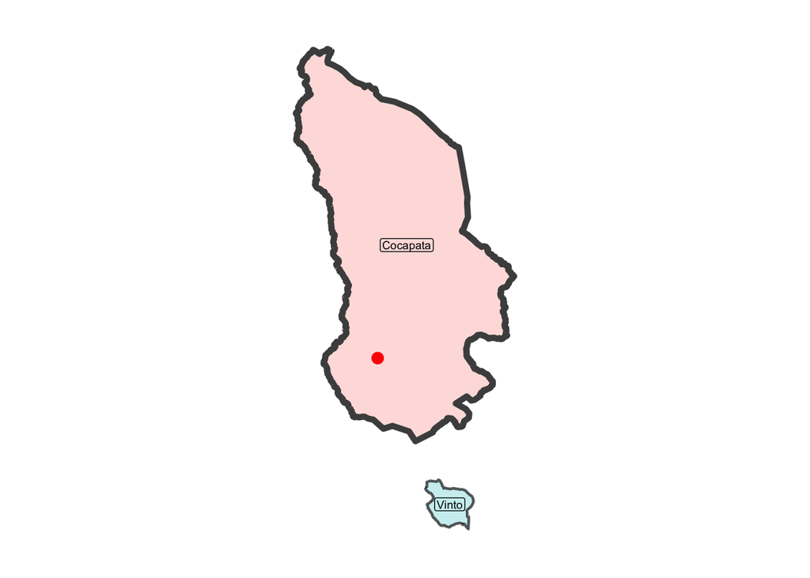

### 3.16 LA ESPERANZA — 11004456413-D

**Current GADM municipality:** Riberalta (Beni)

| INE Code | Name | INE Municipality | Department | Match Status | = Current GADM |
| --- | --- | --- | --- | --- | --- |
| 08030101050 | LA ESPERANZA | Reyes | Beni | unique_via_spatial |  |
| 08020101021 | LA ESPERANZA | Riberalta | Beni | unique_via_spatial | ✓ |

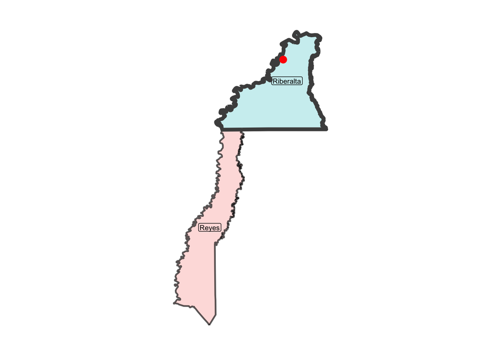

### 3.17 SAN JUAN — 2687212646-D

**Current GADM municipality:** Outside GADM boundaries

**⚠ Municipality names not in current GADM (historical boundaries):** Colcha “K”, Tupiza

| INE Code | Name | INE Municipality | Department | Match Status | = Current GADM |
| --- | --- | --- | --- | --- | --- |
| 05090105034 | SAN JUAN | Colcha “K” | Potosi | unique_via_spatial | NA |
| 05080102175 | SAN JUAN | Tupiza | Potosi | unique_via_spatial | NA |

### 3.18 CERDAS — 2974568761-D

**Current GADM municipality:** Outside GADM boundaries

**⚠ Municipality names not in current GADM (historical boundaries):** Chaquí, Uyuni

| INE Code | Name | INE Municipality | Department | Match Status | = Current GADM |
| --- | --- | --- | --- | --- | --- |
| 05030201046 | CERDAS | Chaquí | Potosi | unique_via_spatial | NA |
| 05120101005 | CERDAS | Uyuni | Potosi | unique_via_spatial | NA |

### 3.19 SANTA BARBARA — 2983059972-D

**Current GADM municipality:** Outside GADM boundaries

**⚠ Municipality names not in current GADM (historical boundaries):** Atocha, Tupiza

| INE Code | Name | INE Municipality | Department | Match Status | = Current GADM |
| --- | --- | --- | --- | --- | --- |
| 05080210001 | SANTA BARBARA | Atocha | Potosi | unique_via_spatial | NA |
| 05080111179 | SANTA BARBARA | Tupiza | Potosi | unique_via_spatial | NA |

### 3.20 CALAZAYA — 3375577208-D

**Current GADM municipality:** Outside GADM boundaries

**⚠ Municipality names not in current GADM (historical boundaries):** Tinguipaya, Tomave, Villa de Sacaca

| INE Code | Name | INE Municipality | Department | Match Status | = Current GADM |
| --- | --- | --- | --- | --- | --- |
| 05010202710 | CALAZAYA | Tinguipaya | Potosi | unique_via_spatial | NA |
| 05120206001 | CALAZAYA | Tomave | Potosi | unique_via_usca | NA |
| 05070101235 | CALAZAYA | Villa de Sacaca | Potosi | unique_via_spatial | NA |

### 3.21 LAGUNILLAS — 3542574010-D

**Current GADM municipality:** Incahuasi (Chuquisaca)

| INE Code | Name | INE Municipality | Department | Match Status | = Current GADM |
| --- | --- | --- | --- | --- | --- |
| 01030401011 | LAGUNILLAS | Icla | Chuquisaca | unique_via_spatial |  |
| 01070302045 | LAGUNILLAS | Incahuasi | Chuquisaca | unique_via_spatial | ✓ |

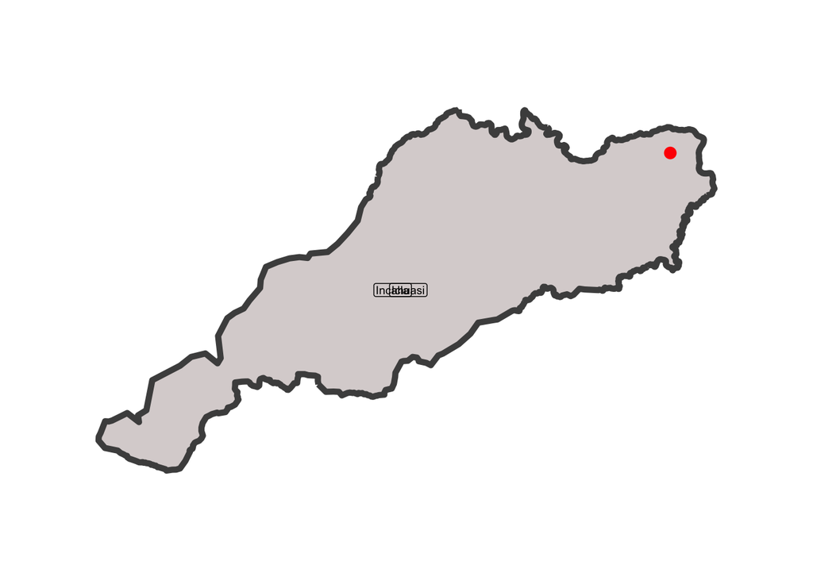

### 3.22 VILLA NUEVA — 3571821422-D

**Current GADM municipality:** Outside GADM boundaries

**⚠ Municipality names not in current GADM (historical boundaries):** Betanzos, Puna

| INE Code | Name | INE Municipality | Department | Match Status | = Current GADM |
| --- | --- | --- | --- | --- | --- |
| 05030103031 | VILLA NUEVA | Betanzos | Potosi | unique_via_spatial | NA |
| 05110108033 | VILLA NUEVA | Puna | Potosi | unique_via_spatial | NA |

### 3.23 CHAQUI — 3802405575-D

**Current GADM municipality:** Outside GADM boundaries

**⚠ Municipality names not in current GADM (historical boundaries):** Chaquí, Puna

| INE Code | Name | INE Municipality | Department | Match Status | = Current GADM |
| --- | --- | --- | --- | --- | --- |
| 05030201010 | CHAQUI | Chaquí | Potosi | unique_via_spatial | NA |
| 05110108047 | CHAQUI | Puna | Potosi | unique_via_spatial | NA |

### 3.24 CKOCHAS — 3816816574-D

**Current GADM municipality:** Outside GADM boundaries

**⚠ Municipality names not in current GADM (historical boundaries):** Ckochas, Puna

| INE Code | Name | INE Municipality | Department | Match Status | = Current GADM |
| --- | --- | --- | --- | --- | --- |
| 05110302008 | CKOCHAS | Ckochas | Potosi | unique_via_spatial | NA |
| 05110304008 | CKOCHAS | Ckochas | Potosi | unique_via_spatial | NA |
| 05110101106 | CKOCHAS | Puna | Potosi | unique_via_spatial | NA |

### 3.25 LAGUNILLAS — 4082343764-D

**Current GADM municipality:** Lagunillas (Santa Cruz)

| INE Code | Name | INE Municipality | Department | Match Status | = Current GADM |
| --- | --- | --- | --- | --- | --- |
| 07010501082 | LAGUNILLAS | El Torno | Santa Cruz | unique_via_spatial |  |
| 07070101011 | LAGUNILLAS | Lagunillas | Santa Cruz | unique_via_spatial | ✓ |

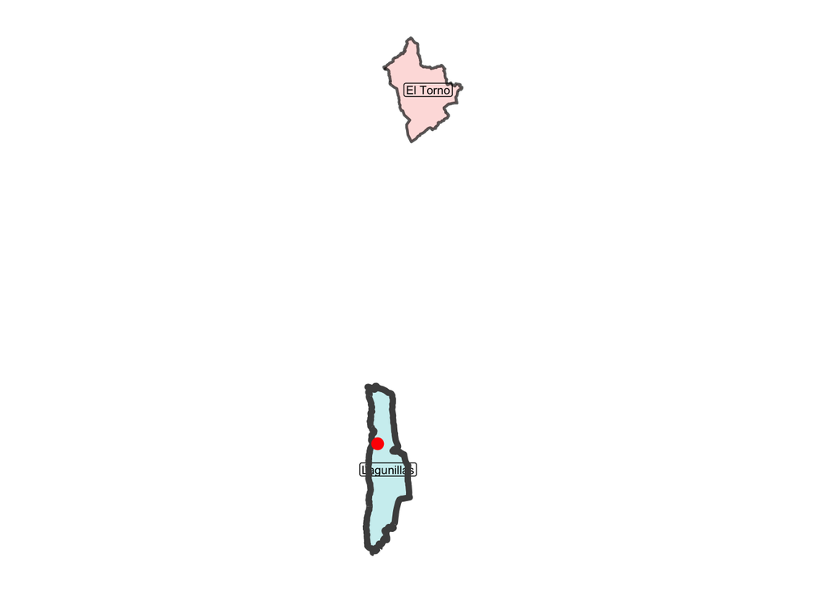

### 3.26 KAKA CHACA — 4189507861-D

**Current GADM municipality:** Challapata (Oruro)

| INE Code | Name | INE Municipality | Department | Match Status | = Current GADM |
| --- | --- | --- | --- | --- | --- |
| 04020101020 | KAKA CHACA | Challapata | Oruro | unique_via_spatial | ✓ |
| 04140104020 | KAKA CHACA | Huari | Oruro | unique_via_spatial |  |

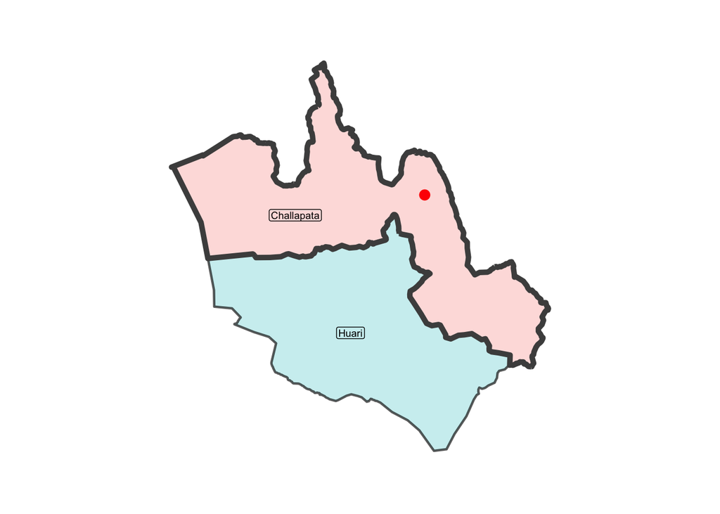

### 3.27 CHAIRAPATA — 4275850717-D

**Current GADM municipality:** Outside GADM boundaries

**⚠ Municipality names not in current GADM (historical boundaries):** Colquechaca, Ocurí

| INE Code | Name | INE Municipality | Department | Match Status | = Current GADM |
| --- | --- | --- | --- | --- | --- |
| 05040101124 | CHAIRAPATA | Colquechaca | Potosi | unique_via_spatial | NA |
| 05040404002 | CHAIRAPATA | Ocurí | Potosi | unique_via_spatial | NA |

### 3.28 AMAYA PAMPA — 4420220567-D

**Current GADM municipality:** Outside GADM boundaries

**⚠ Municipality names not in current GADM (historical boundaries):** Chayanta, Colquechaca

| INE Code | Name | INE Municipality | Department | Match Status | = Current GADM |
| --- | --- | --- | --- | --- | --- |
| 05020201001 | AMAYA PAMPA | Chayanta | Potosi | unique_via_spatial | NA |
| 05040104109 | AMAYA PAMPA | Colquechaca | Potosi | unique_via_spatial | NA |

### 3.29 ENTRE RIOS — 4450635740-D

**Current GADM municipality:** Outside GADM boundaries

**⚠ Municipality names not in current GADM (historical boundaries):** Chayanta, Tupiza

| INE Code | Name | INE Municipality | Department | Match Status | = Current GADM |
| --- | --- | --- | --- | --- | --- |
| 05020201004 | ENTRE RIOS | Chayanta | Potosi | unique_via_spatial | NA |
| 05080101080 | ENTRE RIOS | Tupiza | Potosi | unique_via_spatial | NA |

### 3.30 CATAVI — 4460133706-D

**Current GADM municipality:** Outside GADM boundaries

**⚠ Municipality names not in current GADM (historical boundaries):** Colcha “K”, Llallagua

| INE Code | Name | INE Municipality | Department | Match Status | = Current GADM |
| --- | --- | --- | --- | --- | --- |
| 05090102012 | CATAVI | Colcha “K” | Potosi | unique_via_spatial | NA |
| 05020301008 | CATAVI | Llallagua | Potosi | unique_via_spatial | NA |

### 3.31 SAN PEDRO DE BUENA VISTA — 4605198152-D

**Current GADM municipality:** Outside GADM boundaries

**⚠ Municipality names not in current GADM (historical boundaries):** S.P. De Buena Vista, Toro Toro

| INE Code | Name | INE Municipality | Department | Match Status | = Current GADM |
| --- | --- | --- | --- | --- | --- |
| 05050101025 | SAN PEDRO DE BUENA VISTA | S.P. De Buena Vista | Potosi | unique_via_spatial | NA |
| 05050203025 | SAN PEDRO DE BUENA VISTA | Toro Toro | Potosi | unique_via_spatial | NA |

### 3.32 GUADALUPE — 4635717039-D

**Current GADM municipality:** Vallegrande (Santa Cruz)

| INE Code | Name | INE Municipality | Department | Match Status | = Current GADM |
| --- | --- | --- | --- | --- | --- |
| 07100501012 | GUADALUPE | San Pedro | Santa Cruz | unique_via_spatial |  |
| 07080104010 | GUADALUPE | Vallegrande | Santa Cruz | unique_via_spatial | ✓ |

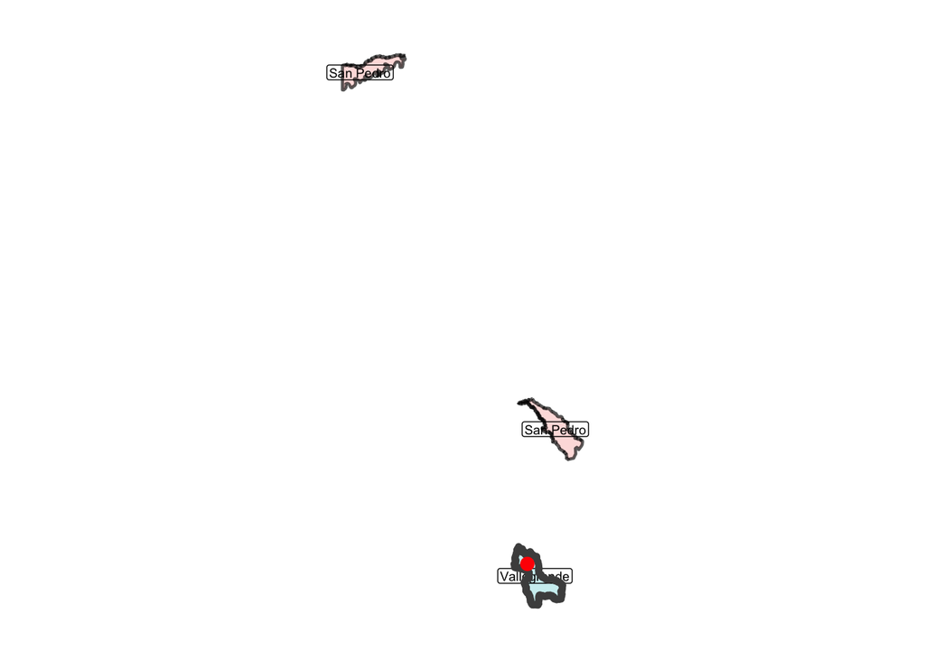

### 3.33 VILA VILA — 4835431740-D

**Current GADM municipality:** Vila Vila (Cochabamba)

**⚠ Municipality names not in current GADM (historical boundaries):** Bolívar

| INE Code | Name | INE Municipality | Department | Match Status | = Current GADM |
| --- | --- | --- | --- | --- | --- |
| 03150105702 | VILA VILA | Bolívar | Cochabamba | unique_via_spatial |  |
| 03130201010 | VILA VILA | Vila Vila | Cochabamba | unique_via_spatial | ✓ |

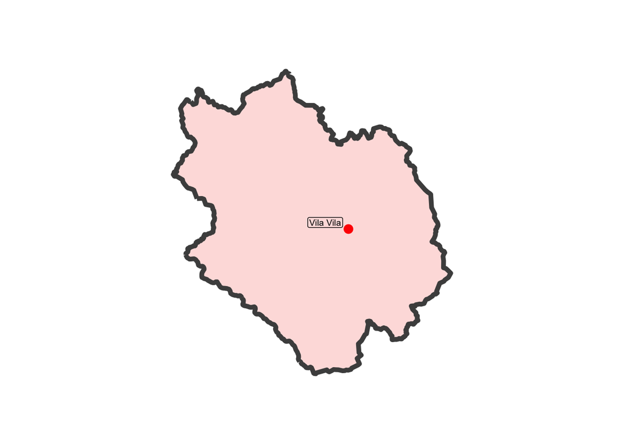

### 3.34 MOLLEBAMBA — 4970824334-D

**Current GADM municipality:** Papel Pampa (La Paz)

| INE Code | Name | INE Municipality | Department | Match Status | = Current GADM |
| --- | --- | --- | --- | --- | --- |
| 02180203007 | MOLLEBAMBA | Papel Pampa | La Paz | unique_via_spatial | ✓ |
| 02040302738 | MOLLEBAMBA | Pto. Carabuco | La Paz | unique_via_spatial |  |

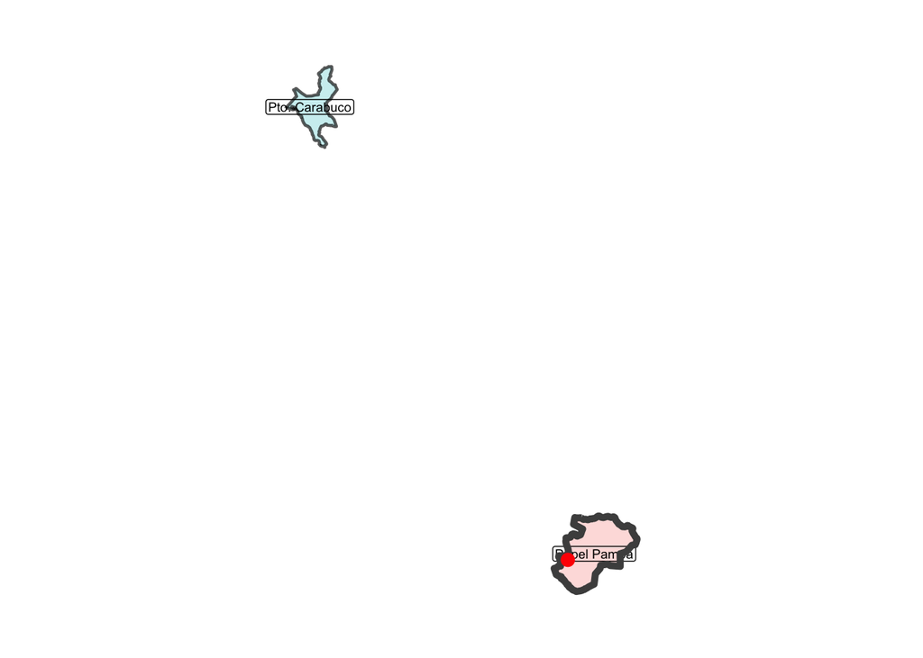

### 3.35 EL TORNO — 5066733732-D

**Current GADM municipality:** El Torno (Santa Cruz)

| INE Code | Name | INE Municipality | Department | Match Status | = Current GADM |
| --- | --- | --- | --- | --- | --- |
| 07010501032 | EL TORNO | El Torno | Santa Cruz | unique_via_spatial | ✓ |
| 07100101008 | EL TORNO | Montero | Santa Cruz | unique_via_spatial |  |

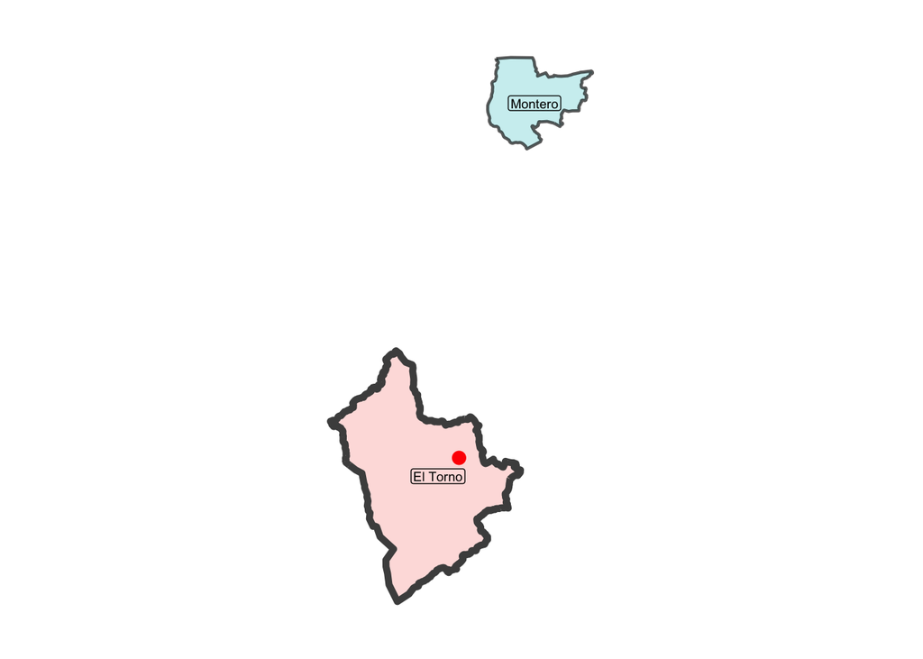

### 3.36 SAN JOSE — 5111581947-D

**Current GADM municipality:** La Guardia (Santa Cruz)

| INE Code | Name | INE Municipality | Department | Match Status | = Current GADM |
| --- | --- | --- | --- | --- | --- |
| 07140302043 | SAN JOSE | Carmen Rivero Torrez | Santa Cruz | unique_via_spatial |  |
| 07010406002 | SAN JOSE | La Guardia | Santa Cruz | unique_via_spatial | ✓ |

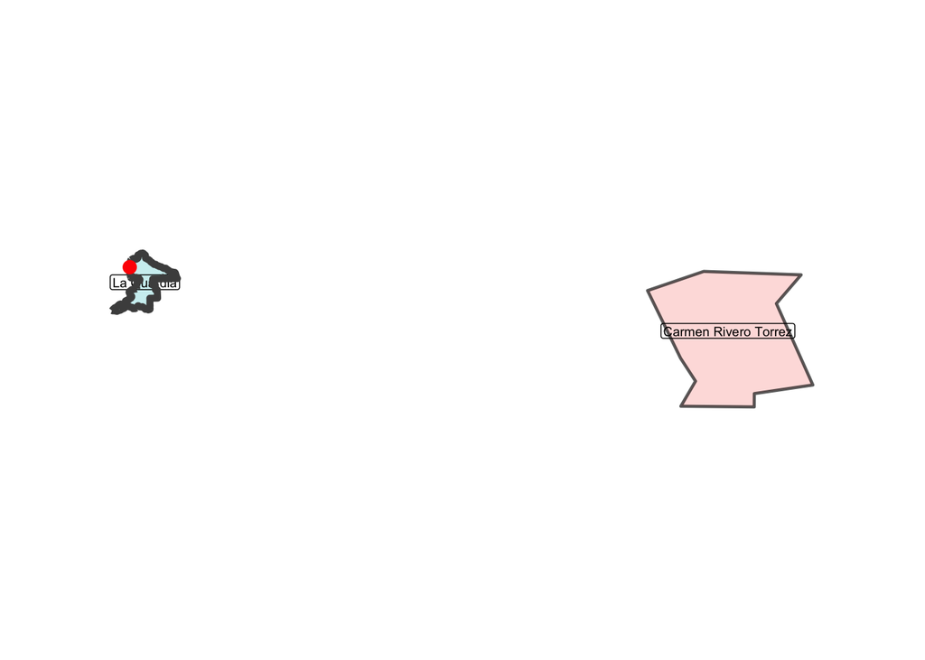

### 3.37 VILLA VERDE — 5113960717-D

**Current GADM municipality:** Arbieto (Cochabamba)

| INE Code | Name | INE Municipality | Department | Match Status | = Current GADM |
| --- | --- | --- | --- | --- | --- |
| 03040301009 | VILLA VERDE | Arbieto | Cochabamba | unique_via_spatial | ✓ |
| 03140303006 | VILLA VERDE | San Benito | Cochabamba | unique_via_spatial |  |

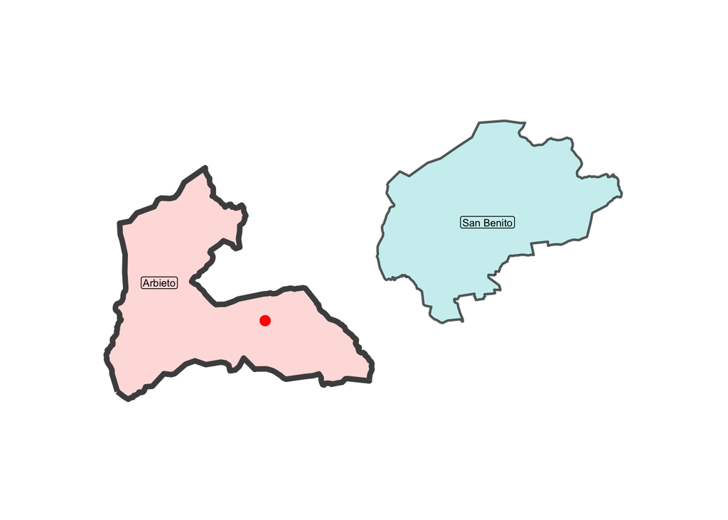

### 3.38 SAN BENITO — 5162697884-D

**Current GADM municipality:** San Benito (Cochabamba)

| INE Code | Name | INE Municipality | Department | Match Status | = Current GADM |
| --- | --- | --- | --- | --- | --- |
| 03120502907 | SAN BENITO | Puerto Villarroel | Cochabamba | unique_via_spatial |  |
| 03140301018 | SAN BENITO | San Benito | Cochabamba | unique_via_spatial | ✓ |

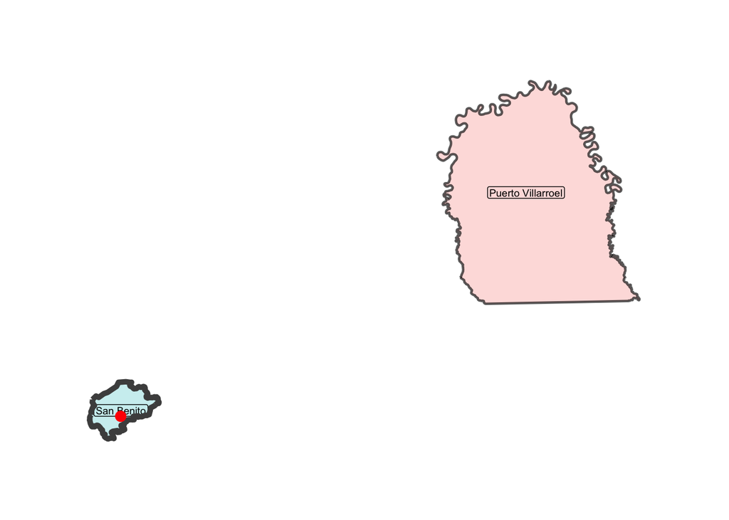

### 3.39 MILLA MILLA — 5166032528-D

**Current GADM municipality:** Sica Sica (La Paz)

| INE Code | Name | INE Municipality | Department | Match Status | = Current GADM |
| --- | --- | --- | --- | --- | --- |
| 02130107016 | MILLA MILLA | Sica Sica | La Paz | unique_via_spatial | ✓ |
| 02100601013 | MILLA MILLA | Villa Libertad Licoma | La Paz | unique_via_spatial |  |

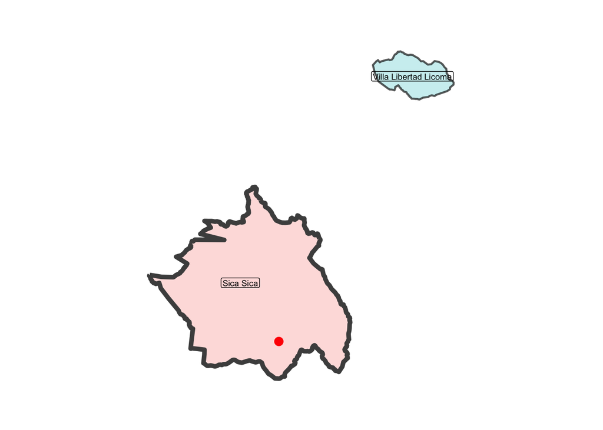

### 3.40 CHAUPI SUYO — 5229793288-D

**Current GADM municipality:** Vinto (Cochabamba)

| INE Code | Name | INE Municipality | Department | Match Status | = Current GADM |
| --- | --- | --- | --- | --- | --- |
| 03160101741 | CHAUPI SUYO | Tiraque | Cochabamba | unique_via_spatial |  |
| 03090401703 | CHAUPI SUYO | Vinto | Cochabamba | unique_via_spatial | ✓ |

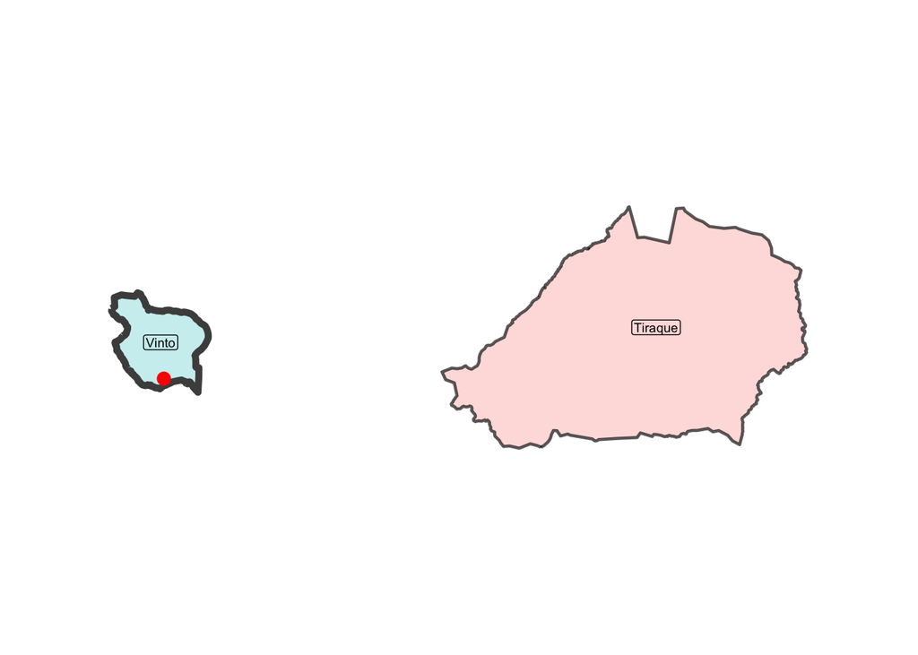

### 3.41 INDEPENDENCIA — 5487644523-D

**Current GADM municipality:** Independencia (Cochabamba)

| INE Code | Name | INE Municipality | Department | Match Status | = Current GADM |
| --- | --- | --- | --- | --- | --- |
| 03030101009 | INDEPENDENCIA | Independencia | Cochabamba | unique_via_spatial | ✓ |
| 03100301334 | INDEPENDENCIA | Villa Tunari | Cochabamba | unique_via_spatial |  |

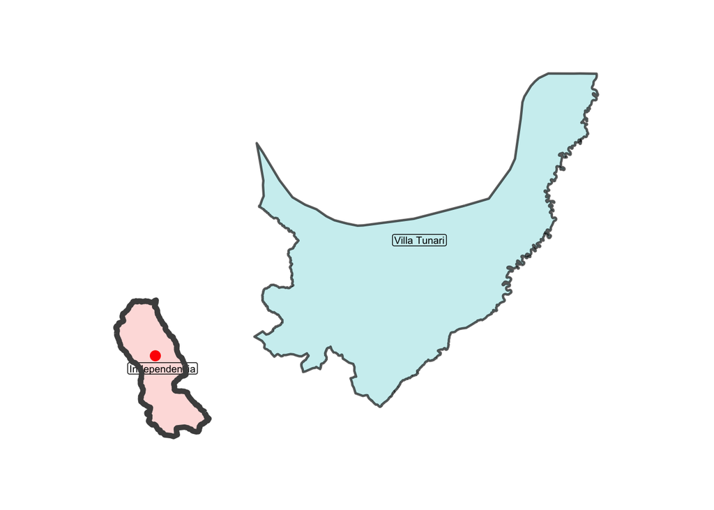

### 3.42 COLLPANI — 5502087055-D

**Current GADM municipality:** Luribay (La Paz)

| INE Code | Name | INE Municipality | Department | Match Status | = Current GADM |
| --- | --- | --- | --- | --- | --- |
| 02060501701 | COLLPANI | Combaya | La Paz | unique_via_spatial |  |
| 02090101002 | COLLPANI | Luribay | La Paz | unique_via_spatial | ✓ |

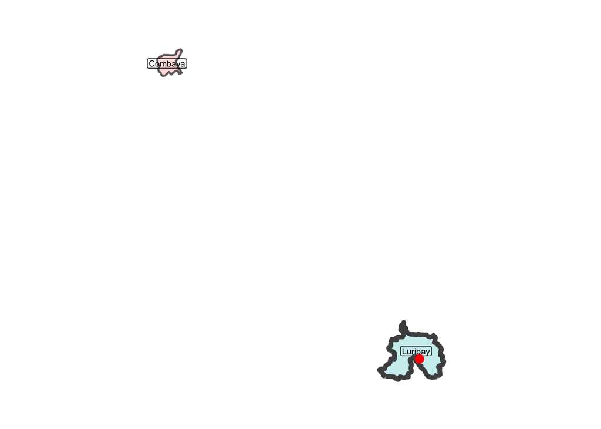

### 3.43 VILOCO — 5699367728-D

**Current GADM municipality:** Cairoma (La Paz)

**⚠ Municipality names not in current GADM (historical boundaries):** Waldo Ballivián

| INE Code | Name | INE Municipality | Department | Match Status | = Current GADM |
| --- | --- | --- | --- | --- | --- |
| 02090504013 | VILOCO | Cairoma | La Paz | unique_via_spatial | ✓ |
| 02030601045 | VILOCO | Waldo Ballivián | La Paz | unique_via_spatial |  |

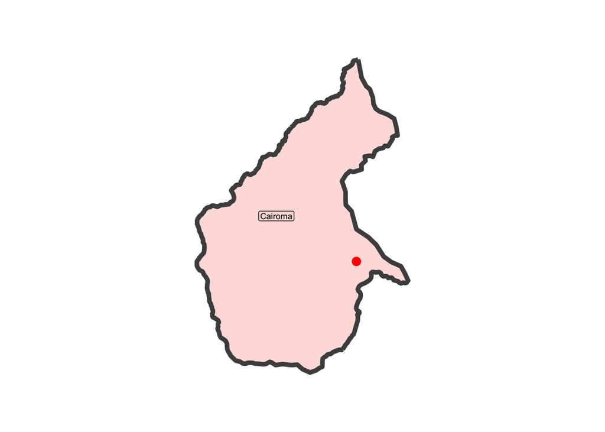

### 3.44 COCAPATA — 5718210142-D

**Current GADM municipality:** Cocapata (Cochabamba)

| INE Code | Name | INE Municipality | Department | Match Status | = Current GADM |
| --- | --- | --- | --- | --- | --- |
| 03030303002 | COCAPATA | Cocapata | Cochabamba | unique_via_spatial | ✓ |
| 03120304005 | COCAPATA | Pocona | Cochabamba | unique_via_spatial |  |

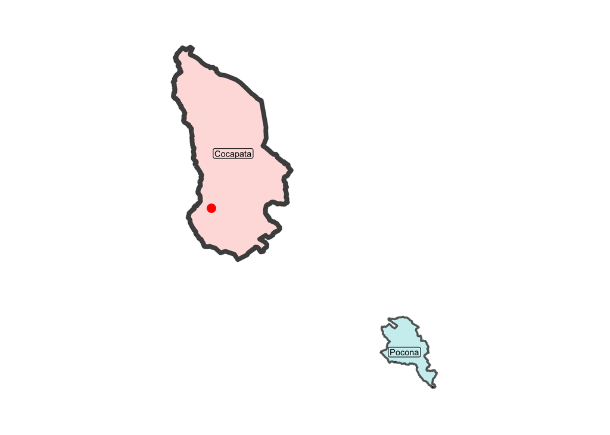